# Markov Clustering and weighted metagene construction

Jane Merlevede & Andrei Zinovyev

03/15/21

# 1 Introduction

We described here the analyses performed on ES gene expression datasets. Our goal is to identify robust (across different datasets) mechanims active in ES tumors.

This report described in details the way we used to identify communities and to build weighted metagenes.

The inputs needed are:

- correlations obtained from RBH analyses
- metagenes computed on each dataset

This work is in the scope of D3.1 iPC deliverable.

Here we focused on Ewing sarcoma, for which we gathered 20 datasets:

- 5 bulk datasets of patients
- 4 single cell cell lines
- 8 single cell PDX
- 3 single cell controls (including 2 full embryos GSE137804)

# 2 Communities detection

We want to identify processes that are found across several datasets, making them quite robust. Processes identified in one dataset only may be technical artefact, even if we cannot exclude that they are real rare signal, found in a particular cohort. The idea is that a process will be identified by several components in the different datasets and they will form a group, called here a community.

We used Markov Clustering algorithm to detect the communities. This is applied to an adjacency matrix, a symmetric matrix giving the correlations (best reciprocal correlation) found between the components.

## 2.1 Compute an adjacency matrix

## 2.2 Markov Clustering

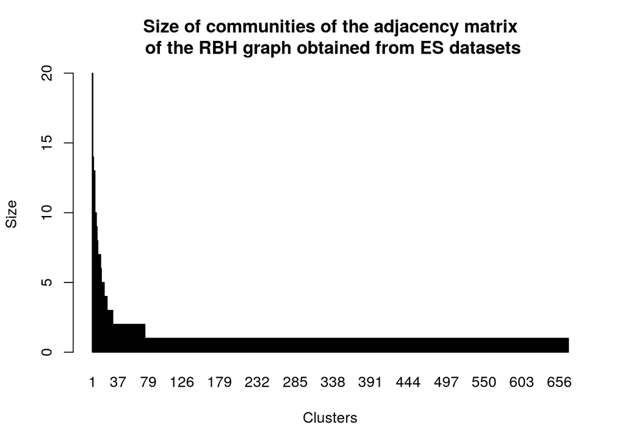

Using Markov Clustering, 668 communities are identified.

We can have a look at the distribution of the size (=nb of components) of the communities.

Then, we kept only communities containing at least 3 components.

## 2.3 Robust communities

We here considered communities containing at least 3 components, and defined them as robust communities.

29 communities with 3 components are identified.

# 3 Build “weigthed metagenes”

“weigthed metagenes” characterizing the communities: a matrix with genes in row and nb of communities in columns The weight for a gene is the average of its (positive or negative) weigths (depending on the orientation of the heavy tail) in the components belonging to the community